# Week 2 Lab

SeungHeonDoh 2018/02/21

```r
library(dplyr)
library(ggplot2)
library(statsr)
```

### Data Description

This data frame contains 133 observations and 6 variables, where every row records a shot taken by Kobe Bryant. The shot variable in this dataset indicates whether the shot was a hit (H) or a miss (M).

Just looking at the string of hits and misses, it can be difficult to gauge whether or not it seems like Kobe was shooting with a hot hand. One way we can approach this is by considering the belief that hot hand shooters tend to go on shooting streaks. For this lab, we define the length of a shooting streak to be the number of consecutive baskets made until a miss occurs.

#### Data load

```r
data(kobe_basket)
```

```r
kobe_streak <- calc_streak(kobe_basket$shot)
```

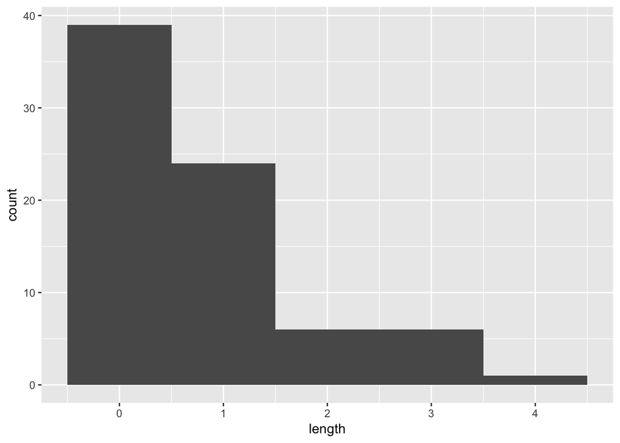

```r
ggplot(data = kobe_streak, aes(x = length)) +
  geom_histogram(binwidth = 1)
```

#### Simulating a basketball player who has independent shots uses the same mechanism that we use to simulate a coin flip. To simulate a single shot from an independent shooter with a shooting percentage of 50% we type,

```r
shot_outcomes <- c("H", "M")
sim_basket <- sample(shot_outcomes, size = 1, replace = TRUE)
```